# Plantilla Modelado y evaluación de los datos

**Objetivo:** Construir, entrenar e interpretar modelos de aprendizaje automático utilizando los datos preparados, y evaluar su desempeño para seleccionar la mejor alternativa.

> Para cada subsección encontrarás una celda *Markdown* con instrucciones y una celda de *Python* para tu código.

```python
# Importes generales
import numpy as np
import pandas as pd
import matplotlib.pyplot as plt
import seaborn as sns

import joblib

# Selección y validación de modelos
from sklearn.model_selection import train_test_split, cross_val_score, StratifiedKFold, GridSearchCV, RandomizedSearchCV



# Métricas estrictamente para clasificación
from sklearn.metrics import accuracy_score, precision_score, recall_score, f1_score, roc_auc_score, confusion_matrix

# Modelos de clasificación
from sklearn.linear_model import LogisticRegression
from sklearn.tree import DecisionTreeClassifier       # Árboles de decisión
from sklearn.ensemble import RandomForestClassifier
from sklearn.svm import SVC                           # Máquinas de Vectores de Soporte
from sklearn.neural_network import MLPClassifier      # Redes neuronales (Perceptrón Multicapa)
```

## 1. Selección del tipo de modelo

- Determinar si el problema es de clasificación, regresión o agrupamiento.
- Elegir los algoritmos adecuados según el tipo de problema y la naturaleza de los datos. Ejemplos:
  - Clasificación: Regresión logística, Árboles de decisión, Random Forest, SVM, Redes neuronales.
  - Regresión: Regresión lineal, Random Forest Regressor, XGBoost, Redes neuronales.
  - Agrupamiento: K-Means, DBSCAN, Hierarchical Clustering

Después de un proceso de análisis en grupo, hemos determinado que nuestro reto del Spaceship Titan es un problema de clasificación binaria supervisada porque la variable objetivo **transported**, es categórica booleana y busca determinar a que categoría pertenece cada pasajero. Consideramos que es un reto de supervisión porque contamos con el conjunto de datos de entrenamiento que contiene ya la variable respuesta conocida para entrenar el modelo.

Por último, es binaria dado a que lo que nuestros modelos buscarán predecir es ver si es verdadero o falso la variable objetivo.

## 2. Separación de los conjuntos de datos

- Confirma la **separación train/test** (y opcionalmente *validation*).
- Asegura **reproducibilidad** (semilla aleatoria).

```python
# Escribe tu código aquí

# Se cargan los datos
df = pd.read_csv("data_for_modeling.csv")
df_limpio = df.copy()

# Separar variables predictoras (X) y objetivo (y)
X = df_limpio.drop('Transported', axis=1)
y = df_limpio['Transported'].astype(int)

# Al definir random_state=42, garantizamos que el corte de datos sea siempre igual.
# stratify=y asegura que la proporción de clases se mantenga en Train y Test.
X_train, X_test, y_train, y_test = train_test_split(
    X, y,
    test_size=0.2,
    random_state=42,
    stratify=y
)

# Se confirma separación de separación entre Train y Test
print("--- Confirmación de la Separación Train/Test ---")
print(f"Total de datos disponibles: {len(X)} registros")
print(f"Conjunto de Entrenamiento (Train): {len(X_train)} registros ({len(X_train)/len(X):.1%})")
print(f"Conjunto de Prueba (Test): {len(X_test)} registros ({len(X_test)/len(X):.1%})")

print("\nEquilibrio de clases ('Transported') en Entrenamiento:")
print(y_train.value_counts(normalize=True).round(4))

print("\nEquilibrio de clases ('Transported') en Prueba:")
print(y_test.value_counts(normalize=True).round(4))
```

```
--- Confirmación de la Separación Train/Test ---
Total de datos disponibles: 8693 registros
Conjunto de Entrenamiento (Train): 6954 registros (80.0%)
Conjunto de Prueba (Test): 1739 registros (20.0%)

Equilibrio de clases ('Transported') en Entrenamiento:
Transported
1    0.5036
0    0.4964
Name: proportion, dtype: float64

Equilibrio de clases ('Transported') en Prueba:
Transported
1    0.5037
0    0.4963
Name: proportion, dtype: float64
```

## 3. Entrenamiento del modelo

- Ajustar el modelo a los datos de entrenamiento mediante el método fit().
- Controlar el proceso con métricas de entrenamiento (por ejemplo, accuracy, pérdida, etc.).
- Guardar los parámetros y configuraciones del modelo

```
Entrenando Árbol de Decisión...

--- Resultados del Modelo Base (Árbol de Decisión) ---
Exactitud (Accuracy): 0.7568
Precisión (Precision): 0.7649
Sensibilidad (Recall): 0.7466
Puntuación F1 (F1-Score): 0.7556
```

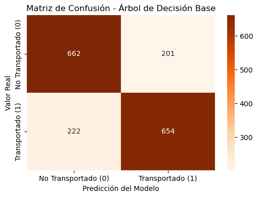

```python
# Escribe tu código aquí

# 1. Inicializar el modelo
# - random_state=42: Asegura que la construcción de las ramas sea reproducible.
# - max_depth: Por ahora lo dejamos por defecto (crecerá hasta clasificar todo o llegar a hojas puras).
modelo_arbol = DecisionTreeClassifier(random_state=42)

# 2. Entrenar (Ajustar) el modelo con los datos de entrenamiento
print("Entrenando Árbol de Decisión...")
modelo_arbol.fit(X_train, y_train)

# 3. Hacer predicciones sobre los datos de prueba
y_pred_arbol = modelo_arbol.predict(X_test)

# 4. Calcular métricas de evaluación
accuracy_arbol = accuracy_score(y_test, y_pred_arbol)
precision_arbol = precision_score(y_test, y_pred_arbol)
recall_arbol = recall_score(y_test, y_pred_arbol)
f1_arbol = f1_score(y_test, y_pred_arbol)

print("\n--- Resultados del Modelo Base (Árbol de Decisión) ---")
print(f"Exactitud (Accuracy): {accuracy_arbol:.4f}")
print(f"Precisión (Precision): {precision_arbol:.4f}")
print(f"Sensibilidad (Recall): {recall_arbol:.4f}")
print(f"Puntuación F1 (F1-Score): {f1_arbol:.4f}")

# 5. Visualizar la Matriz de Confusión
cm_arbol = confusion_matrix(y_test, y_pred_arbol)

plt.figure(figsize=(6, 4))
# Usamos un mapa de color 'Oranges' para diferenciarlo visualmente de la regresión logística
sns.heatmap(cm_arbol, annot=True, fmt='d', cmap='Oranges',
            xticklabels=['No Transportado (0)', 'Transportado (1)'],
            yticklabels=['No Transportado (0)', 'Transportado (1)'])
plt.title('Matriz de Confusión - Árbol de Decisión Base')
plt.ylabel('Valor Real')
plt.xlabel('Predicción del Modelo')
plt.show()
```

## 4. Validación y ajuste de hiperparámetros

- Aplicar técnicas de validación cruzada (cross-validation) para medir la robustez del modelo.
- Utilizar métodos de optimización de hiperparámetros:
  - Grid Search
  - Random Search
  - Bayesian Optimization o frameworks como Optuna.
- Ajustar los parámetros que maximizan el desempeño del modelo.

```
Aplicando Validación Cruzada al Árbol de Decisión base...
Exactitud en cada partición: [0.7426312  0.7325665  0.73184759 0.72537743 0.73956835]
Exactitud Media (Base): 0.7344
Desviación Estándar: 0.0061

Iniciando Grid Search para optimización de hiperparámetros...
Fitting 5 folds for each of 160 candidates, totalling 800 fits

--- Resultados de la Optimización ---
Mejores Parámetros Encontrados: {'criterion': 'entropy', 'max_depth': 15, 'min_samples_leaf': 20, 'min_samples_split': 50}
Mejor Exactitud durante Validación Cruzada: 0.7836

--- Evaluación Final del Árbol Optimizado ---
Exactitud (Accuracy): 0.7976
Precisión (Precision): 0.8119
Sensibilidad (Recall): 0.7785
Puntuación F1 (F1-Score): 0.7949
```

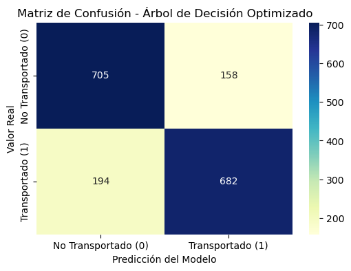

```python
# Escribe tu código aquí

# --- 1. Validación Cruzada del modelo base ---
print("Aplicando Validación Cruzada al Árbol de Decisión base...")
puntuaciones_cv_arbol = cross_val_score(modelo_arbol, X_train, y_train, cv=5, scoring='accuracy')

print(f"Exactitud en cada partición: {puntuaciones_cv_arbol}")
print(f"Exactitud Media (Base): {puntuaciones_cv_arbol.mean():.4f}")
print(f"Desviación Estándar: {puntuaciones_cv_arbol.std():.4f}")


# --- 2. Ajuste de Hiperparámetros con Grid Search ---
print("\nIniciando Grid Search para optimización de hiperparámetros...")

# Definimos los parámetros específicos para "podar" el árbol
parametros_grid_arbol = {
    'criterion': ['gini', 'entropy'],       # Criterios matemáticos para decidir cómo dividir las ramas
    'max_depth': [5, 10, 15, 20, None],     # Profundidad máxima del árbol (None = sin límite)
    'min_samples_split': [2, 10, 20, 50],   # Mínimo de muestras necesarias para dividir un nodo interno
    'min_samples_leaf': [1, 5, 10, 20]      # Mínimo de muestras que debe tener una "hoja" final
}

# Configurar el GridSearchCV
grid_search_arbol = GridSearchCV(
    estimator=DecisionTreeClassifier(random_state=42),
    param_grid=parametros_grid_arbol,
    cv=5,                   # 5 particiones
    scoring='accuracy',
    n_jobs=-1,              # Procesamiento en paralelo
    verbose=1
)

# Entrenar el Grid Search
grid_search_arbol.fit(X_train, y_train)

# Guardar el mejor modelo
mejor_modelo_arbol = grid_search_arbol.best_estimator_

print("\n--- Resultados de la Optimización ---")
print(f"Mejores Parámetros Encontrados: {grid_search_arbol.best_params_}")
print(f"Mejor Exactitud durante Validación Cruzada: {grid_search_arbol.best_score_:.4f}")


# --- 3. Evaluación Final en el Conjunto de Prueba ---
y_pred_arbol_opt = mejor_modelo_arbol.predict(X_test)

print("\n--- Evaluación Final del Árbol Optimizado ---")
print(f"Exactitud (Accuracy): {accuracy_score(y_test, y_pred_arbol_opt):.4f}")
print(f"Precisión (Precision): {precision_score(y_test, y_pred_arbol_opt):.4f}")
print(f"Sensibilidad (Recall): {recall_score(y_test, y_pred_arbol_opt):.4f}")
print(f"Puntuación F1 (F1-Score): {f1_score(y_test, y_pred_arbol_opt):.4f}")

# Graficamos la nueva matriz de confusión
cm_arbol_opt = confusion_matrix(y_test, y_pred_arbol_opt)
plt.figure(figsize=(6, 4))
sns.heatmap(cm_arbol_opt, annot=True, fmt='d', cmap='YlGnBu',
            xticklabels=['No Transportado (0)', 'Transportado (1)'],
            yticklabels=['No Transportado (0)', 'Transportado (1)'])
plt.title('Matriz de Confusión - Árbol de Decisión Optimizado')
plt.ylabel('Valor Real')
plt.xlabel('Predicción del Modelo')
plt.show()
```

## 5. Evaluación del modelo

- Evalúa en **X_test, y_test** con métricas adecuadas:
  - Clasificación: *accuracy*, *precision*, *recall*, *F1*, **ROC-AUC**, matriz de confusión.
  - Regresión: **MAE**, **RMSE**, **R²**.
  - Agrupamiento: **Silhouette Score**, **Davies–Bouldin**.
- Analiza **sesgo y varianza** (under/overfitting).

```
--- Evaluación en Conjunto de Prueba (X_test, y_test) ---
Accuracy:  0.7976
Precision: 0.8119
Recall:    0.7785
F1-Score:  0.7949
ROC-AUC:   0.8829

--- Análisis de Sesgo y Varianza ---
Rendimiento en Entrenamiento (Train): 0.8303
Rendimiento en Prueba (Test):         0.7976
Diferencia (Train - Test):            0.0327

Diagnóstico: BALANCE ADECUADO. El modelo generaliza bien y la brecha entre Train y Test es aceptable.
```

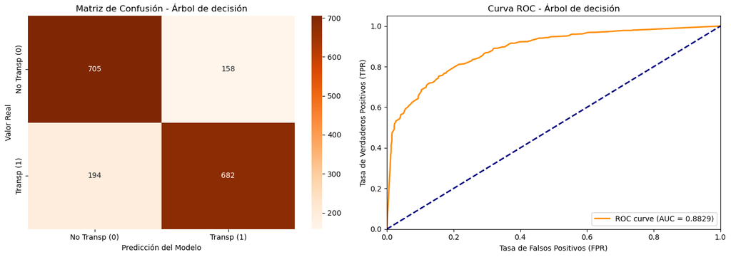

```python
# Escribe tu código aquí

from sklearn.metrics import accuracy_score, precision_score, recall_score, f1_score, roc_auc_score, confusion_matrix, roc_curve
import matplotlib.pyplot as plt
import seaborn as sns

# --- 1. Generar predicciones y probabilidades para Train y Test ---
# Las predicciones de Train son estrictamente para el análisis de overfitting
y_pred_train = mejor_modelo_arbol.predict(X_train)
y_pred_test = mejor_modelo_arbol.predict(X_test)

# predict_proba nos da la probabilidad de pertenecer a la clase 1 (Transported) para el ROC-AUC
y_prob_train = mejor_modelo_arbol.predict_proba(X_train)[:, 1]
y_prob_test = mejor_modelo_arbol.predict_proba(X_test)[:, 1]

# --- 2. Cálculo de métricas principales en Test ---
accuracy = accuracy_score(y_test, y_pred_test)
precision = precision_score(y_test, y_pred_test)
recall = recall_score(y_test, y_pred_test)
f1 = f1_score(y_test, y_pred_test)
roc_auc = roc_auc_score(y_test, y_prob_test)

print("--- Evaluación en Conjunto de Prueba (X_test, y_test) ---")
print(f"Accuracy:  {accuracy:.4f}")
print(f"Precision: {precision:.4f}")
print(f"Recall:    {recall:.4f}")
print(f"F1-Score:  {f1:.4f}")
print(f"ROC-AUC:   {roc_auc:.4f}\n")

# --- 3. Análisis de Sesgo y Varianza (Underfitting / Overfitting) ---
# Comparamos el Accuracy de Entrenamiento vs Prueba
acc_train = accuracy_score(y_train, y_pred_train)
diferencia = acc_train - accuracy

print("--- Análisis de Sesgo y Varianza ---")
print(f"Rendimiento en Entrenamiento (Train): {acc_train:.4f}")
print(f"Rendimiento en Prueba (Test):         {accuracy:.4f}")
print(f"Diferencia (Train - Test):            {diferencia:.4f}\n")

if diferencia > 0.05:
    print("Diagnóstico: OVERFITTING (Alta Varianza). El modelo memorizó los datos de entrenamiento y pierde rendimiento con datos nuevos.")
elif acc_train < 0.70 and accuracy < 0.70:
    print("Diagnóstico: UNDERFITTING (Alto Sesgo). El modelo es demasiado simple y no logra aprender bien los patrones.")
else:
    print("Diagnóstico: BALANCE ADECUADO. El modelo generaliza bien y la brecha entre Train y Test es aceptable.")

# --- 4. Visualización: Matriz de Confusión y Curva ROC ---
fig, axes = plt.subplots(1, 2, figsize=(14, 5))

# 4.1 Matriz de Confusión
cm = confusion_matrix(y_test, y_pred_test)
sns.heatmap(cm, annot=True, fmt='d', cmap='Oranges', ax=axes[0],
            xticklabels=['No Transp (0)', 'Transp (1)'],
            yticklabels=['No Transp (0)', 'Transp (1)'])
axes[0].set_title('Matriz de Confusión - Árbol de decisión')
axes[0].set_ylabel('Valor Real')
axes[0].set_xlabel('Predicción del Modelo')

# 4.2 Curva ROC
fpr, tpr, umbrales = roc_curve(y_test, y_prob_test)
axes[1].plot(fpr, tpr, color='darkorange', lw=2, label=f'ROC curve (AUC = {roc_auc:.4f})')
axes[1].plot([0, 1], [0, 1], color='navy', lw=2, linestyle='--') # Línea de modelo aleatorio
axes[1].set_xlim([0.0, 1.0])
axes[1].set_ylim([0.0, 1.05])
axes[1].set_xlabel('Tasa de Falsos Positivos (FPR)')
axes[1].set_ylabel('Tasa de Verdaderos Positivos (TPR)')
axes[1].set_title('Curva ROC - Árbol de decisión')
axes[1].legend(loc="lower right")

plt.tight_layout()
plt.show()
```

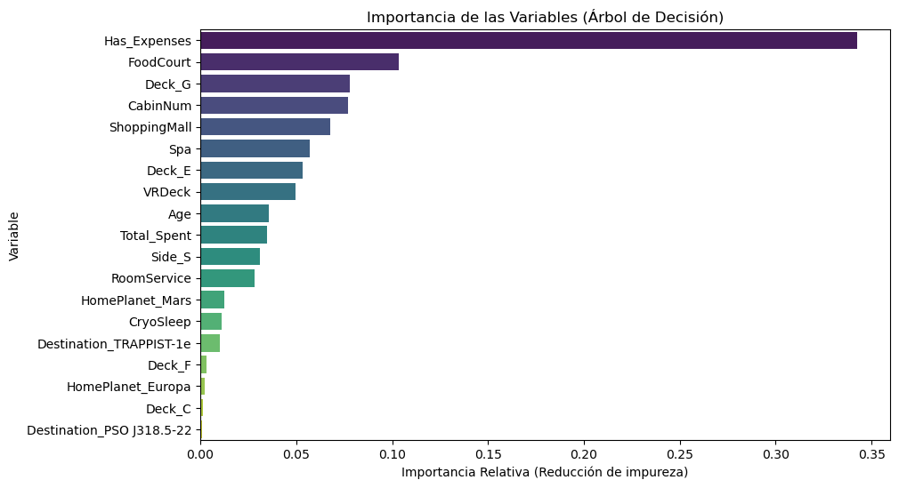

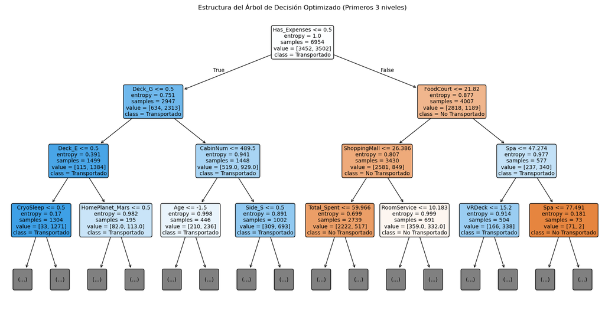

```python
#evaluacion extra

import pandas as pd
import matplotlib.pyplot as plt
import seaborn as sns
from sklearn.tree import plot_tree

# --- 1. Importancia de las Variables (Feature Importance) ---
importancias_arbol = mejor_modelo_arbol.feature_importances_

df_importancia_arbol = pd.DataFrame({
    'Variable': X.columns,
    'Importancia': importancias_arbol
})

# Filtramos las variables que tienen una importancia mayor a 0 para limpiar el gráfico
df_importancia_arbol = df_importancia_arbol[df_importancia_arbol['Importancia'] > 0]
df_importancia_arbol = df_importancia_arbol.sort_values(by='Importancia', ascending=False)

plt.figure(figsize=(10, 6))
sns.barplot(x='Importancia', y='Variable', data=df_importancia_arbol, palette='viridis')
plt.title('Importancia de las Variables (Árbol de Decisión)')
plt.xlabel('Importancia Relativa (Reducción de impureza)')
plt.ylabel('Variable')
plt.show()


# --- 2. Visualización de las Reglas del Árbol ---
plt.figure(figsize=(20, 10))
# Dibujamos solo los primeros 3 niveles
plot_tree(mejor_modelo_arbol,
          feature_names=X.columns,
          class_names=['No Transportado', 'Transportado'],
          filled=True,
          rounded=True,
          max_depth=3,
          fontsize=10)
plt.title('Estructura del Árbol de Decisión Optimizado (Primeros 3 niveles)')
plt.show()
```